# Oral Exam

This is the official record for the doctoral oral exam of Lydia Yao. This document will walk you through the fundamentals of microbiome data, an introduction to causal mediation analysis, Lydia’s first paper on distance-based methodology, and a discussion on potential future research directions in this area.

# Chapter 1: Introduction to the Microbiome

## 1.1 The Human Microbiome

The human microbiome refers to the complete collection of microorganisms—bacteria, archaea, fungi, protists, and viruses—that reside on or within human tissues and biofluids, as well as the specific anatomical sites they inhabit, including the gastrointestinal tract, skin, oral cavity, respiratory system, and reproductive organs. The concept broadly covers both the microbial communities and their interactions with the host. Notably, the number of microbial cells in the human body is estimated to be on par with—or even exceed—that of human cells (Sender, Fuchs, and Milo 2016), highlighting the vast scale and importance of these communities. These microorganisms can exist in a commensal or mutualistic relationship with the host, playing key roles in digestion, immune system development, and protection against pathogens.

Our understanding has vastly expanded with the advent of high-throughput sequencing and other omics technologies. These sequencing techniques encompass five key phases: design, sampling, sequencing, analysis, and reporting. The sequencing step warrents additional attention since it offers a range of strategies (Yi et al. 2024). Mainstream methods include Amplicon sequencing, which targets marker genes like 16S rDNA for rapid and cost-effective profiling as shown in Figure 1.1 (Lundberg 2013). Metagenomic Next-Generation Sequencing (mNGS) sequences all genetic material to provide species or strain-level insights and functional information but can be challenged by host DNA contamination (Gu, Miller, and Chiu 2019). Targeted Next-Generation Sequencing (tNGS) enriches specific pathogenic genomes to reduce host interference (Gu, Miller, and Chiu 2022). Additionally, emerging technologies such as MobiMicrobe high-throughput microbial single-cell genome sequencing and 2bRAD-M simplified metagenomic sequencing address limitations of traditional methods by enabling precise strain-level analysis and effective handling of degraded or low-biomass samples (Yi et al. 2024).

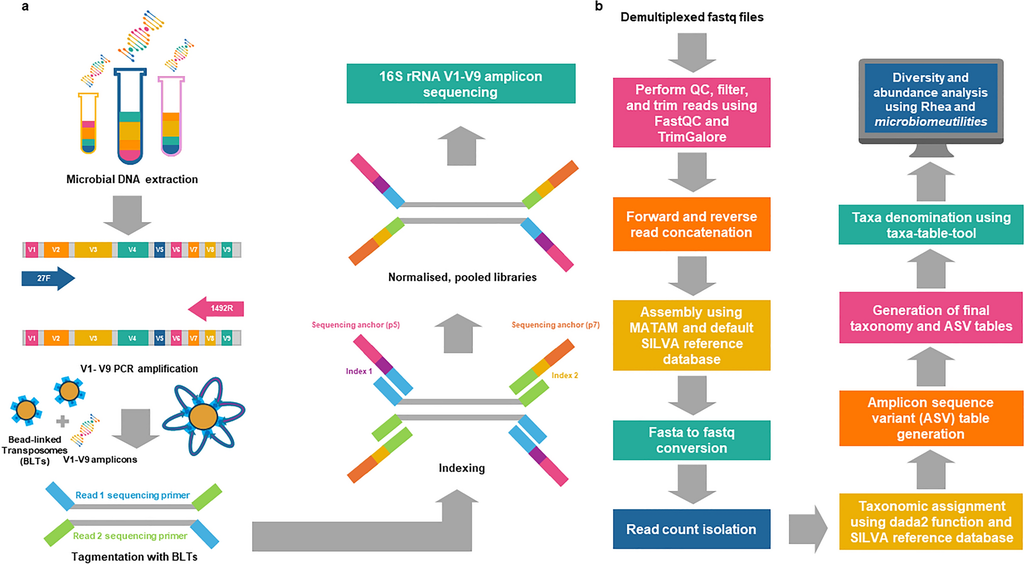

Figure 1.1: Overview of the library preparation, sequencing, and 16S rRNA amplicon re-assembly.

The field continues to face significant challenges. Microbiome data are enormous in both volume and complexity, characterized by high dimensionality, sparsity, and variability across individuals and environments (Mousa, Chehadeh, and Husband 2022). While established infrastructures for data sharing exist, the interdisciplinary and multi-omic nature of microbiome studies often results in difficulties identifying, curating, and integrating relevant datasets. Best practices for data deposition and metadata annotation require substantial effort, and there is still a need for microbiome-specific resources to ensure reproducibility.

## 1.2 Data Structure

Microbiome data are typically organized as abundance tables where each row represents a sample and each column corresponds to a microbial feature such as an operational taxonomic unit (OTU) or an amplicon sequence variant (ASV)(Faust et al. 2012) (Callahan, McMurdie, and Holmes 2017) . These tables capture the frequency or relative abundance of microbial taxa across different samples, providing a quantitative snapshot of the community.

Depending on the analysis goals, researchers may work with raw counts or relative abundances. *Raw counts* directly reflect sequencing read depths but are influence by total reads per sample, complicating comparisons without additional normalization. *Relative abundance* expresses each feature’s count as a proportion of the sample total, enabling more straightforward cross-sample comparison but introducing a unit-sum constraint that can induce spurious correlations (Gloor et al. 2017). In addition to these methods, researchers often apply the centered log-ratio (CLR) transformation to microbiome data. The CLR transformation converts compositional data from the constrained simplex into real Euclidean space by taking the logarithm of the ratio of each component to the geometric mean of the entire composition (Kaul et al. 2017). This approach helps to mitigate the closure constraint inherent in compositional data.

$$g(x) =
(\prod^D_{i=1}x_{i,j})^{\frac{1}{D}}$$
$$CLT = \log(\frac{x_{i,j}}{g(x)})$$

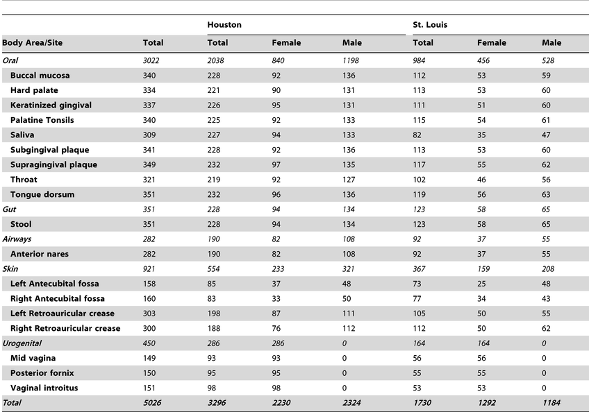

Figure 1.2: 16S rRNA gene sequencing data from the Human Microbiome Project used to assess microbial co-occurrence relationships in the human microbiome.

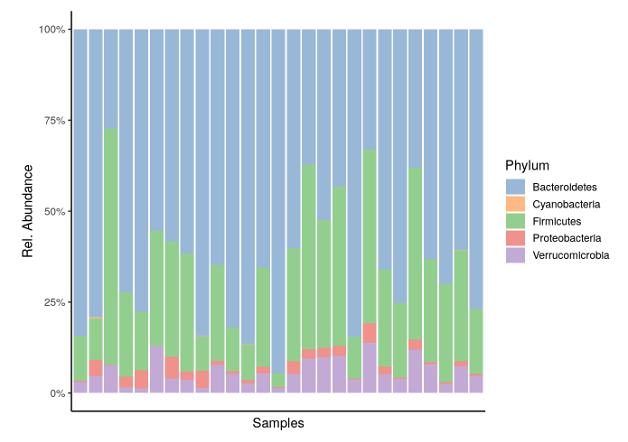

A notable characteristic of microbiome data is its high dimensionality and inherent sparsity. With thousands of microbial features typically measured, many taxa are present in only a subset of samples, resulting in a zero-inflated data matrix (Li 2015). These zeros may arise from both biological sparsity and technical artifacts such as sequencing drop-out or detection limits (Kaul et al. 2017). These issues can complicate traditional statistical analyses and necessitates specialized computational methods, such as compositional data analysis and advanced normalization techniques, to correct for variability in sequencing depth and to manage the relative nature of the data.

Furthermore, the compositional nature of microbiome datasets, where the total abundance for each sample is constrained to a constant sum, introduces unique challenges in interpreting the data (Tsilimigras and Fodor 2016). This constraint means that the observed abundances are interdependent, requiring the use of transformations like CLR to enable meaningful comparisons between samples. Overall, a thorough understanding of the data structure, including both the abundance tables and the associated metadata, is essential for accurately characterizing microbial communities and drawing reliable biological conclusions.

# Chapter 2: A Distance-Based Mediation Approach

## 2.1 Research Question

Understanding how exposures impact outcomes via the microbiome is critical for unraveling complex biological pathways. The primary research question of this study is: **How can we achieve robust inference for the between-subject direct effect (DE) and mediation effect (ME) when the mediator consists of complex microbiome data using a distance-based approach of Beta-Diversity?** This inquiry focuses on distinguishing the direct influence of an exposure from the indirect pathway mediated through the microbiome, providing clarity on their individual contributions.

In pursuing this question, the objective is to reliably quantify both DE and ME to inform downstream analyses and potential interventions. By obtaining accurate estimates of these effects, the study aims to enhance our understanding of the causal relationships at play, ultimately guiding the development of more targeted therapeutic strategies and improving the overall interpretation of microbiome-mediated effects in health outcomes.

## 2.2 Previous Approaches

Several methodologies have been proposed to tackle the challenges of estimating mediation effects when dealing with high-dimensional microbiome data. Traditional approaches such as Principal Component Analysis (PCA) have been used to reduce the dimensionality of the data by extracting key components that capture most of the variance in the microbial profiles. While PCA can simplify the data and mitigate multicollinearity, its transformation of the original variables into principal components can obscure direct interpretations regarding individual taxa and their specific mediating roles.

In contrast, more targeted variable selection techniques have been introduced to improve causal inference. The Two-stage Adaptive Lasso (TSAL) approach, for example, is designed to first screen for potential mediators and then refine the selection to focus on those with the strongest associations, thereby balancing dimensionality reduction with interpretability (Yang et al. 2023). Although TSAL can dramatically shrink the dimension of the mediator space, its two‐step nature can propagate selection errors: informative mediators with weaker marginal signals may be discarded before the second stage.

Newer methods like the Sparse Compositional Mediation Model have been developed to incorporate sparsity-inducing penalties to identify key mediators while accounting for the fact that microbial relative abundances sum to a constant (Sohn, Lu, and Li 2022). This framework directly incorporates the unit‐sum constraint into the penalty structure, improving interpretability of the selected taxa. However, it still relies on tuning parameter selection via cross‐validation, which can be unstable when sample sizes are modest or when rare taxa carry cumulative effects.

Similarly, the Sparse Microbial Causal Mediation Model extends this framework by directly modeling both the direct and indirect effects in a sparse setting (Wang et al. 2020). By modeling both pathways in a unified penalized likelihood, it achieves more coherent inference of mediation effects. Nonetheless, in settings with extreme zero‐inflation or highly correlated taxa, the standard penalty functions may over‐shrink clusters of correlated mediators, masking subtle community‐level mediation patterns.

In contrast to these methods, RDistMed preserves the full microbiome feature set by operating on pairwise distance matrices rather than selecting individual taxa. Rather than removing low‐abundance or weakly associated OTUs, this method aggregates information through robust distance‐based models, ensuring that both strong and weak signals contribute to the mediation analysis. Inclusivity, robustness, and computational efficiency reframes mediation through a completely different lens.

## 2.3 Methods

Fully verified approaches are essential when inferring between-subject direct and mediation effects in complex microbiome studies. We introduce RDistMed—a robust distance-based mediation method that is rigorously validated for reliability and consistency. RDistMed is designed to decompose the overall effect of an exposure into its direct and indirect components, ensuring accurate inference even in the presence of noise and data sparsity inherent to microbiome measurements. By integrating pairwise distance metrics within a carefully constructed estimation framework, our approach delivers stable, reproducible results across diverse datasets.

Within-sample ($\alpha$) diversity metrics—such as Shannon or Simpson indices—summarize the richness or evenness of a single microbial community. Although these measures capture how diverse an individual’s microbiome is, they do not directly quantify how one subject’s community differs from another’s. In contrast, between-subject ($\beta$) diversity metrics measure pairwise dissimilarities across all samples, providing a matrix of distances that reflects compositional shifts between individuals. For causal mediation in microbiome studies, we seek to understand how variation in the microbiome mediates the effect of an exposure on an outcome. This inherently involves comparing subjects. Beta-diversity thus aligns naturally with the counterfactual contrast framework.

The following sections elaborate on the theoretical underpinnings and practical implementation of RDistMed.

### 2.3.1 Data Setup

### Definitions of Data Variables and Their Pairwise Distances

Before performing mediation analysis, we define the four key data variables and specify the corresponding distance functions used to compare pairs of subjects.

- **Covariates ($\mathbf{X}_i$):**
  Each subject $i$ is characterized by a set of pre-exposure covariates, represented as a $p$-dimensional vector:
  $$\mathbf{X}_i = \begin{bmatrix}
  x_{i1} \\
  x_{i2} \\
  \vdots \\
  x_{ip}
  \end{bmatrix} \quad \text{with } \mathbf{X}_i \in \mathbb{R}^p.$$
  The distance between two subjects based on their covariates is defined using the Euclidean distance:

$$\textbf{X}_{i,j}=d_X(i,j) =
\|\mathbf{X}_i - \mathbf{X}_j\|_2 = \sqrt{\sum_{k=1}^{p} (x_{ik} -
x_{jk})^2}$$
.

- **Exposure ($E_i$):**
  The exposure is a binary variable indicating treatment status:
  $$E_i = \begin{cases}
  1 & \text{if subject } i \text{ is exposed}, \\
  0 & \text{if subject } i \text{ is unexposed}.
  \end{cases}$$
  A custom distance function for binary exposure can be defined using One-hot encoding as below. Including discordant pairs (–1) would not contribute to assessing within-group similarity and would confound the comparison that is central to our distance-based approach thus they are ignored in the analysis.
  $$d_E(i,j) =
  \begin{cases}
  1, & \text{if } E_i = E_j = 1,\\[1mm]
  0, & \text{if } E_i = E_j = 0,\\[1mm]
  -1, & \text{if } E_i \neq E_j.
  \end{cases}$$

We can define binary exposure variable $\delta_{11}(\textbf{E}_{i,j})= \{\textbf{1}(E_i = 1,E_j = 1)\}$.

- **Mediator (Microbiome, $\mathbf{M}_i$):**
  The mediator consists of microbiome measurements (e.g., relative abundances of various taxa). One common way to summarize the differences in microbial communities is via the Bray-Curtis distance. For subjects $i$ and $j$, it is given by:
  $$d_M(i,j) = \frac{\sum_{k=1}^{S} \left| m_{ik} - m_{jk}
  \right|}{\sum_{k=1}^{S} \left( m_{ik} + m_{jk} \right)},$$
  where $m_{ik}$ represents the abundance of taxon $k$ in subject $i$, and $S$ is the total number of taxa. For now, we further simplify the process by dichotomizing it into a binary variable.

  Other commonly used beta diversity metrics include the UniFrac metrics (both weighted and unweighted) and the Jaccard index. UniFrac measures incorporate phylogenetic relationships among taxa, quantifying community differences in terms of the fraction of branch lengths that are unique to one sample versus another (Lozupone and Knight 2005). In contrast, the Jaccard index focuses solely on presence/absence data, providing a binary comparison of community composition (Real and Vargas 1996). While our current approach simplifies the mediator by dichotomizing Bray-Curtis distances, these alternative metrics can offer complementary insights depending on the research question and desired level of phylogenetic or compositional detail.

  Let $M_{i,j}^{\textbf{e}} = d_M(i,j|\delta_{\textbf{e}}(\textbf{E}_{i,j}) = 1)$ represent the counterfactual mediators under the exposure pair $\textbf{e} \in \{11,00\}$.
- **Outcome ($Y_i$):**
  The outcome variable, often continuous, reflects the clinical or phenotypic status of each subject. For pairwise comparisons, the outcome distance is defined as the absolute difference:
  $$d_Y(i,j) = \left| Y_i - Y_j \right|.$$
  Let $Y_{i.j}^{\textbf{e}',M_{i,j}^{\textbf{e}}}$ represent the counterfactual outcome under exposure-mediator $(\textbf{e}',M_{i,j}^{\textbf{e}})$. $\textbf{e}'$ and $\textbf{e}$ represent two different sets of possible exposure pairs.

These distance functions form the basis for comparing subjects in our distance-based mediation framework, enabling us to capture variations in covariates, exposure, microbiome profiles, and outcomes across the study population. Figure 2.1 shows an example of the resulting distance matrices. You might notice -1 values inside not only the exposure matrix. Since those cells will be ignored in our analysis, the -1 is carried over from the exposure matrix into the other two matrices.

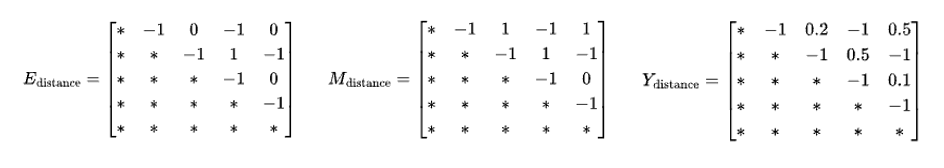

Figure 2.1: Example of sample matrices used in this analysis.

### 2.3.2 Methodology

Figure 2.2 and 2.3 illustrates a standard and a distance based multi-mediator network which we will be modeling here.

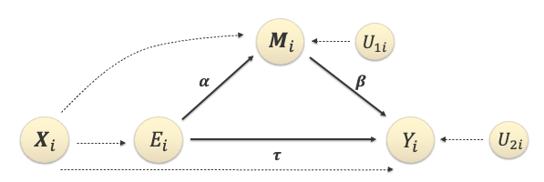

Figure 2.2: A standard multi-mediator model: 𝜶, 𝜷, and 𝝉 are path coefficients; 𝑈_1𝑖 and 𝑈_2𝑖. Are the disturbance variables for mediators 𝑴_𝑖 and outcome 𝑌_𝑖. 𝐸_𝑖 is the exposure or treatment, and 𝑿_𝑖 is a set of pre-exposure variables.

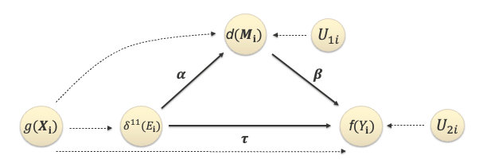

Figure 2.3: A distance based multi-mediator model: 𝜶, 𝜷, and 𝝉 are path coefficients; Respective distance function define each variable.

Our methodology is designed to yield robust estimates of the between-subject direct effect (DE) and mediation effect (ME) by leveraging counterfactual theory and efficient influence functions. Important distinctions have been made between controlled and natural (or pure) direct effects. The controlled direct effect refers to the effect of the exposure when one intervenes to set the mediator to a fixed value that may differ from its observed level (Robins and Greenland 1992). In contrast, the natural or pure direct effect captures the effect of the exposure when one intervenes to set the mediator to the level it would have naturally attained in the absence of exposure, treating the mediator as a random variable (Robins and Greenland 1992). In our methodology, we focus on the natural direct effect which helps in understanding the underlying mechanism while retaining the randomness inherent in the mediator.

The counterfactual parameter is defined as below,
$$\rho = E\left[Y_{i,j}^{11, M_{i,j}^{00}}\right],$$
which is critical for decomposing the total effect into direct and indirect components.

The validity of our approach critically relies on a set of causal assumptions that allow us to interpret the observed data within a counterfactual framework. The first assumption, **counterfactual consistency**, ensures that a subject’s observed outcome and mediator align with the corresponding counterfactual values under the actual exposure history. The second assumption, **strong sequential ignorability**, posits that, conditional on observed pre-exposure covariates, there are no unmeasured confounders affecting both the mediator and the outcome. Finally, the **positivity** assumption guarantees that every covariate profile has a non-zero probability of receiving each level of the exposure and mediator. Under these assumptions, the total effect (TE), mediation effect (ME), and direct effect (DE) are defined as follows:
$$\begin{aligned}
\Psi^{TE}(P_{\theta_0}) &= E\left[Y_{i,j}^{11, M_{i,j}^{11}} -
Y_{i,j}^{00, M_{i,j}^{00}}\right] = \xi^{11} - \xi^{00},\\[1mm]
\Psi^{ME}(P_{\theta_0}) &= E\left[Y_{i,j}^{11, M_{i,j}^{11}}\right]
- E\left[Y_{i,j}^{11, M_{i,j}^{00}}\right] = \xi^{11} - \rho,\\[1mm]
\Psi^{DE}(P_{\theta_0}) &= E\left[Y_{i,j}^{11, M_{i,j}^{00}}\right]
- E\left[Y_{i,j}^{00, M_{i,j}^{00}}\right] = \rho - \xi^{00}.
\end{aligned}$$

#### Estimating $\rho$

To estimate these effects, we develop a joint estimation procedure that employs a combination of working models and a U-statistics based generalized estimating equation (UGEE) approach. Estimating functions that uses kernel functions averaged over all possible subsets of the data is constructed. This approach yields unbiased and efficient estimators for our parameters. A key component of our methodology is the derivation of the Efficient Influence Function (EIF) for our target parameter: the counterfactual mean (Tchetgen and Shpitser 2012). This allows our estimator to be triply robust. Consistency is guaranteed whenever any two of the three nuisance components are correctly specified—namely, when either $(f_{i1},f_{i3})$ or $(f_{i2}, f_{i3})$ is correct. The model also remains consistent in the special case where the outcome‐regression model μ alone is correct. In the ideal setting that all three working models are correctly specified,the estimator continues to attain the semiparametric efficiency bound (Xu et al. 2024).

In this procedure, we define a series of working functions:
$$\begin{aligned}
f_{i1} &= \delta_{11}(E_{i,j}), \quad h_{i1} =
\operatorname{expit}(\alpha_0 + \alpha_1X_{i,j}),\\[1mm]
f_{i2} &= M_{i,j}, \quad h_{i2} = \operatorname{expit}\bigl(\beta_0
+ \beta_1\delta_{11}(E_{i,j}) + \beta_2X_{i,j}\bigr),\\[1mm]
f_{i3} &= Y_{i,j}, \quad h_{i3} = \exp\bigl(\tau_0 +
\tau_1\delta_{11}(E_{i,j}) + \tau_2M_{i,j} + \tau_3X_{i,j}\bigr).
\end{aligned}$$
Furthermore, the estimating function for $\rho$ is constructed as
$$\begin{aligned}
f_{i4} ={}
&\frac{\delta_{11}(E_{i,j})\,h_{i2}\bigl(\delta_{11}(E_{i,j})=0,
X_{i,j}\bigr)}{h_{i1}(X_{i,j})\,h_{i2}\bigl(\delta_{11}(E_{i,j})=1,
X_{i,j}\bigr)}
\Bigl\{Y_{i,j} - h_{i3}\bigl(\delta_{11}(E_{i,j})=1, X_{i,j},
M_{i,j}\bigr)\Bigr\}\\[1mm]
&+\frac{\delta_{00}(E_{i,j})}{1-h_{i1}(X_{i,j})}
\Bigl\{h_{i3}\bigl(\delta_{11}(E_{i,j})=1, X_{i,j},
M_{i,j}\bigr)-\eta^{10}(X_{i,j};P_{\theta_0})\Bigr\} +
\eta^{10}(X_{i,j};P_{\theta_0}),
\end{aligned}$$
with $h_{i4} = \rho$ and
$$\eta^{10}(X_{i,j};P_{\theta_0}) =
\exp\bigl(\tau_0+\tau_1+\tau_2+\tau_3X_{i,j}\bigr)\operatorname{expit}(\beta_0+\beta_2X_{i,j})
+
\exp\bigl(\tau_0+\tau_1+\tau_3X_{i,j}\bigr)\Bigl[1-\operatorname{expit}(\beta_0+\beta_2X_{i,j})\Bigr].$$
Let $\boldsymbol{\theta} = \{\alpha_0, \alpha_1, \beta_0, \beta_1, \beta_2, \tau_0, \tau_1, \tau_2, \tau_3, \rho\}$

The joint estimation procedure is implemented through a UGEE approach that combines these working models with an efficient Newton-Raphson algorithm. By iteratively updating the parameter estimates, the method converges to a solution that minimizes the sum of the efficient influence functions, thereby achieving robust and efficient estimation of $\rho$ and thus DE and ME. This rigorous framework not only accounts for the complex structure of high-dimensional microbiome data but also ensures that the resulting inference is both consistent and reproducible.

#### Estimating $\xi^{ee}$

$\xi^{11}$ and $\xi^{00}$ can be further estimated using the robust joint estimation defined below.

$$\begin{aligned}
f_{i1} &= \delta_{11}(E_{i,j}), \quad h_{i1} =
\operatorname{expit}(\alpha_0 + \alpha_1X_{i,j}),\\[1mm]
f_{i2} &= Y_{i,j}, \quad h_{i2} = \exp\bigl(\tau_0 +
\tau_1\delta_{11}(E_{i,j}) + \tau_2X_{i,j}\bigr).
\end{aligned}$$
Furthermore, the estimating function for $\xi$ is constructed as
$$\begin{aligned}
f_{i3} ={} &\frac{\delta_{11}(E_{i,j})}{h_{i1}(X_{i,j})}
\Bigl\{Y_{i,j} - h_{i2}\bigl(\delta_{11}(E_{i,j})=\textbf{e},
X_{i,j})\Bigr\}+\Bigl\{h_{i2}\bigl(\delta_{11}(E_{i,j})=\textbf{e},
X_{i,j})\Bigl\}
\end{aligned}$$
with $h_{i3} = \xi^{\textbf{e}}$

#### Estimating Effects

The estimation of TE, DE, and ME are dependent upon $\rho$, $\xi^{11}$, and $\xi^{00}$. The Standard error (SE) of these three effects can be further defined using the formulas below and used to calculate P-Values for clinical decision making.

- **Total Effect (TE):** $SE(TE) = SE(\xi^{11} - \xi^{00}) = \sqrt{SE(\xi^{11})^2 + SE(\xi^{00})^2}$
- **Mediation Effect (ME):** $SE(ME) = SE(\xi^{11} - \rho) = \sqrt{SE(\xi^{11})^2 + SE(\rho)^2 + \frac{8}{n}E[(f_{i4} - \rho)(f_{i7}^{11} - \xi^{11})]}$
- **Direct Effect (DE):** $SE(ME) = SE(\rho - \xi^{00}) = \sqrt{SE(\xi^{00})^2 + SE(\rho)^2 + \frac{8}{n}E[(f_{i4} - \rho)(f_{i7}^{00} - \xi^{00})]}$

## 2.4 Results

#### 2.4.1 Simulation for RDistMed

To evaluate the performance of the Robust Distance-based Mediation (RDistMed) method, we conducted a simulation study that assesses the bias and variability of the estimated parameters under different sample sizes and simulation settings. In our simulation, we generate estimates for the model parameters over a large number of replicates, and we then examine the bias, defined as the difference between the true parameter values and the corresponding estimates.

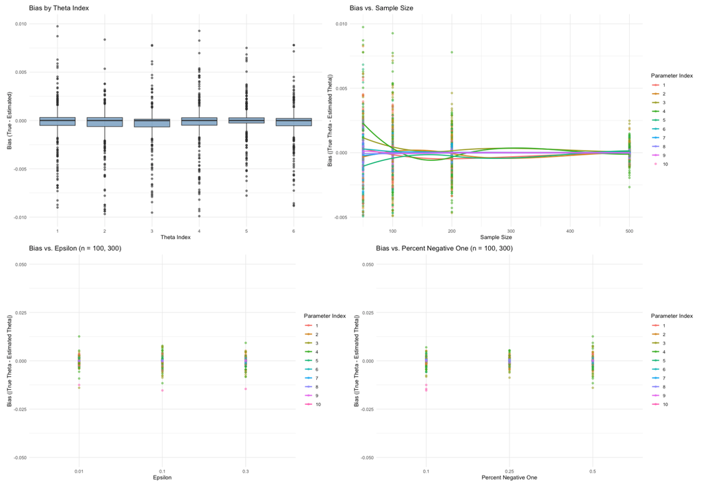

Figure 2.4: Bias of Simulation Results

The values of the coefficients were fixed to zero thus the mediating effect are also fixed to zero to test the type I error rates of the estimates in all combinations where sample size were 100, 200, and 500 respectively. Percent of matrix being -1 is set to be 10%, 25% and 50%. Epsilon Value is set to be 0.1. The results of the type I error rates of the combinations over 1,000 replications were presented in Table 2.1. The results show that error rates are good for lower numbers of negative one indices.

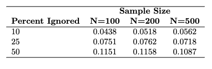

Table 2.1: Type I Error Rates for average of all coefficients

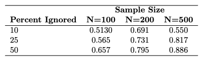

Table 2.2: Power for all coefficients on small coefficients

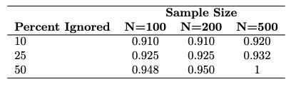

Table 2.3: Power for all coefficients on medium coefficients

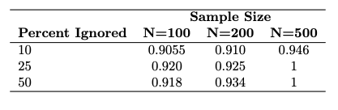

Table 2.4: Power for all coefficients on large coefficients

### 2.4.2 Analysis in Real Data

We applied the RDistMed framework to a dataset comprising of **92 subjects** and **272 OTUs**. The exposure variable is the **Binary Perceived Stress Scale Total Score**, while the confounders include the **Shannon index** (a measure of microbial diversity) and **Age**. The outcome is measured using the **Mencomp (SF-36 Mental Component Scale)**.

By integrating our distance-based methodology with the working models, we obtained the following estimated effects:

- **Total Effect (TE):** $\approx 6.0989 (P < 0.001)$
- **Mediation Effect (ME):** $\approx 0.0088 (P = 0.9956)$
- **Direct Effect (DE):** $\approx 6.0900 (P < 0.001)$

Overall, the real data analysis demonstrates the practical utility of RDistMed in disentangling complex causal mechanisms in microbiome research.

### 2.5 Summary

RDistMed is a robust distance-based mediation analysis framework specifically designed to tackle the challenges posed by high-dimensional microbiome data. By integrating pairwise distance functions with a series of working models—including inverse probability weighting (IPW) for exposure via the true propensity score $h_{i1}(X_{i,j})$, density modeling for mediators $h_{i2}(X_{i,j}, E_\mathbf{i})$, and outcome regression (MSI/OR) $h_{i3}(X_{i,j}, E_\mathbf{i}, M_{i,j})$—RDistMed provides accurate and efficient estimates of both the direct effect (DE) and mediation effect (ME). In addition, the estimator $f_{i4}$, derived from the Gauteax Derivative, facilitates the integration of model components into a unified estimation strategy. Our joint estimation approach via unified generalized estimating equations (UGEE) ensures robust inference even in the presence of zero-inflation, non-linearity, and complex interactions inherent in microbiome data. Simulation studies confirm that RDistMed delivers unbiased and reproducible parameter estimates across a range of conditions, thereby demonstrating its potential for application in real-world microbiome research.

# Chapter 3: Future Directions

The inherent challenges posed by high-dimensional, zero-inflated, and non-linear microbiome data inspire several innovative extensions of our distance-based mediation framework. Below, we outline several promising directions, each addressing distinct aspects of the complexity in microbiome data while striving to improve interpretability and causal inference.

## 3.1 Current Method

Our present implementation of RDistMed begins by reducing the microbiome profile to a binary mediator, based on a threshold applied to pairwise distance measures. While this dichotomization simplifies interpretation and eases computation, it necessarily discards the rich, continuous variation in microbial abundance. To address this, we plan to extend the framework with semi-parametric approaches—such as penalized splines or kernel smoothing—that can flexibly model the continuous mediator and recover more of the underlying biological signal.

To evaluate the robustness of RDistMed, we will conduct sensitivity analyses using alternative distance transforms. In particular, we will apply centered log-ratio (CLR)–based Euclidean distances and phylogenetically informed UniFrac distances in place of our primary beta-diversity measure. By comparing effect estimates and inferential performance across these different distance metrics, we can assess whether—and how—transform choice influences our mediation conclusions. This sensitivity analysis will ensure that our results remain stable under a range of biologically motivated data transformations.

## 3.2 Distance-Based Kernel Regression (DBKR)

The first new idea is to extend our framework using a Distance-Based Kernel Regression (DBKR) approach. In many microbiome studies, the number of microbial features greatly exceeds the number of subjects ($p \gg n$), and binary presence/absence encoding is often beneficial to capture essential signals. DBKR leverages pairwise subject distances computed from a suitable distance metric (e.g., Bray–Curtis) to construct a kernel function:
$$K(d(i,j)) = \exp\left(-\frac{d(i,j)^2}{2\sigma^2}\right),$$
where $d(i,j)$ denotes the pairwise distance between subjects $i$ and $j$, and $\sigma$ is a bandwidth parameter. The regression model is then formulated as
$$Y_{i,j} = \alpha + \sum_{j \neq i} K(d(i,j)) \, \beta \, Y_j +
\varepsilon_{i,j},$$
thereby capturing complex non-linear relationships and interactions within the high-dimensional microbial data.

## 3.3 Simulated Annealing (SA) for Feature Subset Selection in Mediation Analysis

A second promising avenue is to integrate Simulated Annealing (SA) into the distance-based mediation analysis to select a subset of microbial features that best preserve the overall Bray–Curtis distance structure. Let $d_{\text{all}}(i,j)$ be the full Bray–Curtis distance between samples $i$ and $j$, and $d_S(i,j)$ the distance computed using a selected subset $S$ of features. The objective is to minimize the overall discrepancy:
$$\min_S \sum_{i < j} \left|d_{\text{all}}(i,j) - d_S(i,j)\right|,$$
possibly with an additional penalty term to prevent overfitting. SA iteratively updates the subset $S$ by randomly flipping the inclusion or exclusion status of features, guided by a temperature schedule $T(t)$ such that the acceptance probability for a candidate subset with increased discrepancy $\Delta$ is given by
$$P(\text{accept}) = \exp\left(-\frac{\Delta}{T(t)}\right).$$
This strategy is designed to yield a “reduced-yet-informative” set of microbial features that are subsequently incorporated into the mediation model.

## 3.4 Distance Clustering-Based Approach

A third direction involves employing a distance clustering-based approach. In this framework, the pairwise differences between subjects are computed using multivariate distance measures, such as the Mahalanobis distance:
$$d_M(i,j) = \sqrt{(\mathbf{M}_{i,j} - \mathbf{M}_j)^\top \mathbf{S}^{-1}
(\mathbf{M}_{i,j} - \mathbf{M}_j)},$$
where $\mathbf{S}$ is the covariance matrix of the mediator data. Clustering algorithms (e.g., k-means or hierarchical clustering) are then applied to group subject pairs into clusters, with each pair assigned a cluster membership $C_{i,j}$. The clusters can be used to characterize the heterogeneity in microbial differences and further investigated through a secondary analysis that examines how the proportion of pairs in each cluster relates to the exposure-outcome pathway.

## 3.5 Joint Clustering and Estimation

The final direction combines clustering with parameter estimation in a joint framework. In this approach, latent classes (or cluster labels) are estimated simultaneously with the mediation analysis such that the resulting clusters optimally mediate the exposure-outcome relationship. Denote the cluster membership for a pair $(i,j)$ as $C_{i,j}$, and define a score function that quantifies the total indirect effect for a given clustering configuration:
$$\text{Score}(C) = \sum_{k} \left|\text{Indirect Effect}_k\right|.$$
The clustering that maximizes this score is considered optimal, and the mediation model is refit using these latent classes. This joint clustering and estimation framework provides an integrative approach to identifying microbial profiles that are either protective or deleterious with respect to the exposure-outcome pathway.

Each of these future directions leverages distance-based methodologies to address the challenges posed by high-dimensional microbiome data while enhancing the interpretability and causal insights of mediation analyses.

# References

Anouk, CT, Dam S, M Wiesmann, and et al. 2020. “Gut Microbiota from Persons with Attention-Deficit/Hyperactivity Disorder Affects the Brain in Mice.” *Microbiome* 8 (44). https://doi.org/https://doi.org/10.1186/s40168-020-00816-x.

Callahan, B, P McMurdie, and S Holmes. 2017. “Exact Sequence Variants Should Replace Operational Taxonomic Units in Marker-Gene Data Analysis.” *The ISME Journal* 11: 2639–43. https://doi.org/doi.org/10.1038/ismej.2017.119.

Faust, K, F. J. Sathirapongsasuti, J Izard, and N Segata. 2012. “Microbial Co-Occurrence Relationships in the Human Microbiome.” *PLOS Computational Biology* 8. https://doi.org/10.1371/journal.pcbi.1002606.

Gloor, G, J Macklaim, V Pawlowsky-Glahn, and J Egozcue. 2017. “Microbiome Datasets Are Compositional: And This Is Not Optional.” *Front. Microbiol.* 8. https://doi.org//doi.org/10.3389/fmicb.2017.02224.

Gu, W, S Miller, and C Chiu. 2019. “Clinical Metagenomic Next-Generation Sequencing for Pathogen Detection.” *Annual Review of Pathology* 14: 319–38. https://doi.org/10.1146/annurev-pathmechdis-012418-012751.

———. 2022. “Targeted Next Generation Sequencing Is Comparable with Metagenomic Next Generation Sequencing in Adults with Pneumonia for Pathogenic Microorganism Detection.” *Journal of Infection* 85: e127–29. https://doi.org/10.1016/j.jinf.2022.08.022.

Kaul, A, S Mandal, O Davidov, and S Peddada. 2017. “Analysis of Microbiome Data in the Presence of Excess Zeros.” *Front: Microbiol* 8 (2114). https://doi.org/10.3389/fmicb.2017.02114.

Li, Hongzhe. 2015. “Microbiome, Metagenomics, and High-Dimensional Compositional Data Analysis.” *Annual Review of Statistics and Its Applications* 2: 73–94. https://doi.org/10.1146/annurev-statistics-010814-020351.

Lozupone, C, and R Knight. 2005. “UniFrac: A New Phylogenetic Method for Comparing Microbial Communities.” *Appl Environ Microbiol* 71. https://doi.org/10.1128/AEM.71.12.8228-8235.2005.

Lundberg, Yourstone, D. 2013. “Practical Innovations for High-Throughput Amplicon Sequencing.” *Nat Methods* 10: 999–1002. https://doi.org/https://doi.org/10.1038/nmeth.2634.

Mousa, W K, F Chehadeh, and S Husband. 2022. “Recent Advances in Understanding the Structure and Function of the Human Microbiome.” *Frontiers in Microbiology* 13: 825338. https://doi.org/10.3389/fmicb.2022.825338.

Real, R, and M. J. Vargas. 1996. “The Probabilistic Basis of Jaccard’s Index of Similarity.” *Systematic Biology* 45 (3): 380–85. https://doi.org/10.2307/2413572.

Robins, J. M., and S Greenland. 1992. “Identifiability and Exchangeability for Direct and Indirect Effects.” *Epidemiology* 3: 143–55. https://doi.org/10.1097/00001648-199203000-00013.

Sender, R, S Fuchs, and R Milo. 2016. “Are We Really Vastly Outnumbered? Revisiting the Ratio of Bacterial to Host Cells in Humans.” *Cell* 164: 337–40. https://doi.org/10.1016/j.cell.2016.01.013.

Sohn, B. M., J Lu, and H Li. 2022. “A Compositional Mediation Model for a Binary Outcome: Application to Microbiome Studies.” *Bioinformatics* 38: 16–21.

Tchetgen, E, and I Shpitser. 2012. “Semiparametric Theory for Causal Mediation Analysis: Efficiency Bounds, Multiple Robustness and Sensitivity Analysis.” *The Annals of Statistics* 40 (3): 1816–45. https://doi.org/10.1214/12-AOS990.

Tsilimigras, M, and A Fodor. 2016. “Compositional Data Analysis of the Microbiome: Fundamentals, Tools, and Challenges.” *The Microbiome and Epidemiology* 26: 330–35. https://doi.org/10.1016/j.annepidem.2016.03.002.

Wang, C, J Hu, MJ Laser, and H Li. 2020. “Estimating and Testing the Microbial Causal Mediation Effect with High-Dimensional and Compositional Microbiome Data.” *Bioinformatics* 36: 347–55. https://doi.org/10.1093/bioinformatics/btz565.

Xu, Y, N Sani, A Ghassami, and I Shpitser. 2024. “Multiply Robust Causal Mediation Analysis with Continuous Treatments.” *Arxiv*. https://doi.org/10.48550/arXiv.2105.09254.

Yang, S, S Chen, P Wang, and et al. 2023. “TSPLASSO: A Two-Stage Prior LASSO Algorithm for Gene Selection Using Omics Data.” *IEEE Journal of Biomedical and Health Informatics* 28 (1): 526–37. https://doi.org/10.1109/JBHI.2023.3326485.

Yi, X, H Lu, X Liu, and et al. 2024. “Unravelling the Enigma of the Human Microbiome: Evolution and Selection of Sequencing Technologies.” *Microbial Biotechnology* 17. https://doi.org/10.1111/1751-7915.14364.